# MSBI 32000 Winter 2022 Semester

Analysis on HERS dataset

Iyanuoluwa Akinyanju, Nilesh Domah, Muhammad Aji Muharrom

19 March 2022

# Introduction

The dataset is from the Heart and Estrogen/Progestin Replacement Study (HERS). The study was a randomized, placebo-controlled, double-blind clinical trial. Daily hormone therapy of estrogen and progestin was administered during the study to a cohort of postmenopausal women with an intact uterus and confirmed Coronary Heart Disease (CHD).

According to the [paper](https://doi.org/10.1001/jama.280.7.605) the context and the objective of the study are as follows:

> **Context:** Observational studies have found lower rates of Coronary Heart Disease (CHD) in postmenopausal women who take estrogen than in women who do not BUT there is no confirmation via clinical trials.

> **Objective:** To determine if estrogen plus progestin therapy alters the risk for CHD events in postmenopausal women with established coronary disease.

Our version of the study’s dataset is limited in that:

- It had only one year of follow-up while the study ran an annual follow-up on the subjects for 5 years.

This informed our decision to do Exploratory Data Analysis (EDA) and simple statistical analysis on the data set.

# Research Question & Hypotheses

**Research Question**:

- Were there any changes in the parameters measured between the hormone therapy and placebo group?

**Null Hypothesis ($H_0$)**

- There were no significant changes in the measured parameters between both groups.

**Alternative Hypothesis ($H_1$)**

- There were significant changes in the measured parameters between both groups.

# Data Cleaning, Exploration and Wrangling

The data consists of 2763 rows and 37 variables.

- Nineteen (19) variables were measured only at baseline (on enrolment).
- Nine (9) other variables were measured at baseline (on enrolment) and during the 1st year of follow-up (i.e., 9 * 2 = 18).
- This makes a total of 37 variables.

```r
#READING THE .csv file form the current working directory into a new variable called hers
hers <- read.csv("./hersdataset.csv")

#INTROUCING hers and getting value of missing rows
intro <- DataExplorer::introduce(hers)
intro$rows - intro$complete_rows
```

```
[1] 188
```

There are 188 rows (6.8%) with missing values. We choose to eliminate them.

```r
#CREATING A VARIABLE FOR ROWS WITHOUT MISSING VALUES AND PRINTING ITS DIMENSION
hers_complete_rows <- hers[rowSums(is.na(hers))==0,]
dim(hers_complete_rows)
```

```
[1] 2575   37
```

```r
library(tidyverse)
#CREATING CONTROL AND TREATMENT VARIABLES
#BY FILTERING FOR "placebo" Description in Hormone Therapy (HT) of complete rows
hers_control <- hers_complete_rows %>% filter(HT == "placebo")
hers_treatment <- hers_complete_rows %>% filter(HT != "placebo")
dim(hers_control)
```

```
[1] 1306   37
```

```r
dim(hers_treatment)
```

```
[1] 1269   37
```

We see that there are 1306 rows

After removal of missing values, we have 1306 rows for placebo and 1269 rows for hormone therapy, making it 2575 complete rows in the entire dataset.

The following table shows descriptive statistics of the numerical variables.

```r
#SELECTING NUMERICAL VALUES AND FROM THE COMPLETE ROWS
#ROUNDING THEM TO TWO DECIMALS
hers_complete_rows %>%
  select(
    age, tchol, tchol1, TG, TG1, HDL, HDL1, LDL, LDL1,
    glucose, glucose1, weight, weight1, WHR, WHR1, BMI, BMI1) %>%
  psych::describe() %>% round(2) %>% select(-vars, -n) %>% kable()
```

|  | mean | sd | median | trimmed | mad | min | max | range | skew | kurtosis | se |
| --- | --- | --- | --- | --- | --- | --- | --- | --- | --- | --- | --- |
| age | 66.63 | 6.65 | 67.00 | 66.86 | 7.41 | 44.00 | 79.00 | 35.00 | -0.32 | -0.41 | 0.13 |
| tchol | 228.15 | 40.90 | 224.00 | 226.02 | 37.06 | 110.00 | 465.00 | 355.00 | 0.78 | 1.98 | 0.81 |
| tchol1 | 219.22 | 41.12 | 214.00 | 216.70 | 37.06 | 92.00 | 535.00 | 443.00 | 0.97 | 3.16 | 0.81 |
| TG | 165.33 | 63.14 | 157.00 | 161.68 | 66.72 | 31.00 | 476.00 | 445.00 | 0.49 | -0.40 | 1.24 |
| TG1 | 175.19 | 82.42 | 157.00 | 165.41 | 65.23 | 31.00 | 1010.00 | 979.00 | 1.89 | 8.16 | 1.62 |
| HDL | 50.32 | 13.14 | 49.00 | 49.23 | 11.86 | 14.00 | 130.00 | 116.00 | 1.00 | 1.98 | 0.26 |
| HDL1 | 51.83 | 13.89 | 50.00 | 50.74 | 11.86 | 14.00 | 124.00 | 110.00 | 0.88 | 1.32 | 0.27 |
| LDL | 144.77 | 37.80 | 141.00 | 142.45 | 33.80 | 36.80 | 393.40 | 356.60 | 0.95 | 2.71 | 0.75 |
| LDL1 | 132.36 | 39.08 | 128.80 | 129.98 | 34.69 | -20.00 | 450.20 | 470.20 | 1.01 | 3.76 | 0.77 |
| glucose | 110.58 | 36.79 | 98.00 | 102.82 | 14.83 | 29.00 | 298.00 | 269.00 | 2.32 | 5.78 | 0.72 |
| glucose1 | 114.30 | 43.94 | 100.00 | 104.69 | 16.31 | 42.00 | 440.00 | 398.00 | 2.85 | 10.05 | 0.87 |
| weight | 72.65 | 14.60 | 70.90 | 71.60 | 13.94 | 37.60 | 132.00 | 94.40 | 0.72 | 0.56 | 0.29 |
| weight1 | 71.93 | 14.86 | 70.30 | 70.89 | 14.23 | 37.70 | 142.00 | 104.30 | 0.73 | 0.66 | 0.29 |
| WHR | 0.87 | 0.08 | 0.87 | 0.87 | 0.08 | 0.62 | 1.22 | 0.59 | 0.31 | 0.05 | 0.00 |
| WHR1 | 0.87 | 0.08 | 0.86 | 0.86 | 0.08 | 0.61 | 1.15 | 0.54 | 0.30 | -0.07 | 0.00 |
| BMI | 28.54 | 5.45 | 27.74 | 28.14 | 4.98 | 15.49 | 54.13 | 38.64 | 0.79 | 0.86 | 0.11 |
| BMI1 | 28.32 | 5.54 | 27.51 | 27.92 | 5.22 | 14.73 | 54.04 | 39.31 | 0.79 | 0.91 | 0.11 |

There are unrealistic values such as (LDL1 < 0) or (TG1 > 1000), so we choose to eliminate them.

```r
#ELIMINATING THE ROW(S) WITH LESS THAN 0 LDL AND GREATER THAN 1000 TRIGLYCERIDE.
hers_complete_rows <- hers_complete_rows %>% filter(LDL1 > 0) %>% filter(TG1 < 1000)
hers_control <- hers_complete_rows %>% filter(HT == "placebo")
hers_treatment <- hers_complete_rows %>% filter(HT != "placebo")
dim(hers_control)
```

```
[1] 1306   37
```

```r
dim(hers_treatment)
```

```
[1] 1268   37
```

After removal of unrealistic values, we have 1306 rows for placebo and 1268 rows for hormone therapy. This confirms that both values belong to the same subject.

The following table shows the **updated** descriptive statistics of the numerical variables.

```r
#SELECTING NUMERICAL VALUES AND FROM THE COMPLETE ROWS
#ROUNDING THEM TO TWO DECIMALS
hers_complete_rows %>%
  select(
    age, tchol, tchol1, TG, TG1, HDL, HDL1, LDL, LDL1,
    glucose, glucose1, weight, weight1, WHR, WHR1, BMI, BMI1) %>%
  psych::describe() %>% round(2) %>% select(-vars, -n) %>% kable()
```

|  | mean | sd | median | trimmed | mad | min | max | range | skew | kurtosis | se |
| --- | --- | --- | --- | --- | --- | --- | --- | --- | --- | --- | --- |
| age | 66.63 | 6.65 | 67.00 | 66.86 | 7.41 | 44.00 | 79.00 | 35.00 | -0.32 | -0.41 | 0.13 |
| tchol | 228.12 | 40.89 | 224.00 | 226.00 | 37.06 | 110.00 | 465.00 | 355.00 | 0.79 | 1.98 | 0.81 |
| tchol1 | 219.21 | 41.13 | 214.00 | 216.69 | 37.06 | 92.00 | 535.00 | 443.00 | 0.97 | 3.16 | 0.81 |
| TG | 165.29 | 63.12 | 157.00 | 161.63 | 66.72 | 31.00 | 476.00 | 445.00 | 0.49 | -0.40 | 1.24 |
| TG1 | 174.87 | 80.78 | 157.00 | 165.36 | 65.23 | 31.00 | 806.00 | 775.00 | 1.59 | 4.69 | 1.59 |
| HDL | 50.31 | 13.13 | 49.00 | 49.22 | 11.86 | 14.00 | 130.00 | 116.00 | 1.00 | 1.99 | 0.26 |
| HDL1 | 51.82 | 13.89 | 50.00 | 50.73 | 11.86 | 14.00 | 124.00 | 110.00 | 0.88 | 1.32 | 0.27 |
| LDL | 144.76 | 37.81 | 141.00 | 142.44 | 33.80 | 36.80 | 393.40 | 356.60 | 0.95 | 2.71 | 0.75 |
| LDL1 | 132.42 | 38.97 | 128.80 | 130.00 | 34.69 | 18.60 | 450.20 | 431.60 | 1.04 | 3.74 | 0.77 |
| glucose | 110.58 | 36.79 | 98.00 | 102.82 | 14.83 | 29.00 | 298.00 | 269.00 | 2.32 | 5.78 | 0.73 |
| glucose1 | 114.25 | 43.88 | 100.00 | 104.66 | 16.31 | 42.00 | 440.00 | 398.00 | 2.86 | 10.12 | 0.86 |
| weight | 72.65 | 14.60 | 70.90 | 71.60 | 13.94 | 37.60 | 132.00 | 94.40 | 0.72 | 0.56 | 0.29 |
| weight1 | 71.93 | 14.86 | 70.25 | 70.89 | 14.31 | 37.70 | 142.00 | 104.30 | 0.73 | 0.66 | 0.29 |
| WHR | 0.87 | 0.08 | 0.87 | 0.87 | 0.08 | 0.62 | 1.22 | 0.59 | 0.31 | 0.05 | 0.00 |
| WHR1 | 0.87 | 0.08 | 0.86 | 0.86 | 0.08 | 0.61 | 1.15 | 0.54 | 0.29 | -0.07 | 0.00 |
| BMI | 28.54 | 5.45 | 27.74 | 28.14 | 4.99 | 15.49 | 54.13 | 38.64 | 0.79 | 0.86 | 0.11 |
| BMI1 | 28.32 | 5.54 | 27.51 | 27.92 | 5.22 | 14.73 | 54.04 | 39.31 | 0.79 | 0.91 | 0.11 |

The following table shows the updated descriptive statistics of the numerical variables for the **placebo** cohort.

```r
#SELECTING NUMERICAL VALUES AND FROM THE PLACEBO GROUP
#ROUNDING THEM TO TWO DECIMALS
hers_control %>%
  select(
    age, tchol, tchol1, TG, TG1, HDL, HDL1, LDL, LDL1,
    glucose, glucose1, weight, weight1, WHR, WHR1, BMI, BMI1) %>%
  psych::describe() %>% round(2) %>% select(-vars, -n) %>% kable()
```

|  | mean | sd | median | trimmed | mad | min | max | range | skew | kurtosis | se |
| --- | --- | --- | --- | --- | --- | --- | --- | --- | --- | --- | --- |
| age | 66.81 | 6.65 | 68.00 | 67.07 | 7.41 | 44.00 | 79.00 | 35.00 | -0.40 | -0.31 | 0.18 |
| tchol | 228.54 | 40.36 | 224.00 | 226.15 | 37.06 | 123.00 | 465.00 | 342.00 | 0.84 | 2.04 | 1.12 |
| tchol1 | 223.48 | 42.37 | 218.00 | 220.78 | 35.58 | 116.00 | 535.00 | 419.00 | 1.10 | 3.95 | 1.17 |
| TG | 166.64 | 63.55 | 157.00 | 162.80 | 68.20 | 36.00 | 345.00 | 309.00 | 0.47 | -0.63 | 1.76 |
| TG1 | 170.32 | 79.49 | 152.00 | 160.89 | 63.75 | 38.00 | 675.00 | 637.00 | 1.57 | 4.22 | 2.20 |
| HDL | 50.63 | 13.17 | 49.00 | 49.59 | 11.86 | 24.00 | 130.00 | 106.00 | 1.01 | 2.13 | 0.36 |
| HDL1 | 49.50 | 13.13 | 48.00 | 48.37 | 11.86 | 14.00 | 108.00 | 94.00 | 0.95 | 1.38 | 0.36 |
| LDL | 144.57 | 37.33 | 140.60 | 142.15 | 33.66 | 36.80 | 393.40 | 356.60 | 1.01 | 3.05 | 1.03 |
| LDL1 | 139.92 | 39.68 | 134.40 | 137.26 | 33.80 | 45.00 | 450.20 | 405.20 | 1.23 | 4.99 | 1.10 |
| glucose | 111.09 | 37.36 | 98.00 | 103.17 | 14.83 | 56.00 | 298.00 | 242.00 | 2.30 | 5.52 | 1.03 |
| glucose1 | 116.64 | 46.24 | 101.00 | 106.41 | 14.83 | 42.00 | 409.00 | 367.00 | 2.83 | 9.53 | 1.28 |
| weight | 72.44 | 14.70 | 70.60 | 71.32 | 13.94 | 40.80 | 132.00 | 91.20 | 0.75 | 0.58 | 0.41 |
| weight1 | 72.13 | 15.06 | 70.50 | 71.00 | 14.23 | 38.30 | 142.00 | 103.70 | 0.77 | 0.78 | 0.42 |
| WHR | 0.87 | 0.08 | 0.86 | 0.86 | 0.08 | 0.64 | 1.22 | 0.58 | 0.39 | 0.10 | 0.00 |
| WHR1 | 0.87 | 0.08 | 0.86 | 0.86 | 0.08 | 0.70 | 1.12 | 0.42 | 0.35 | -0.29 | 0.00 |
| BMI | 28.50 | 5.48 | 27.60 | 28.10 | 5.09 | 16.68 | 51.47 | 34.79 | 0.75 | 0.63 | 0.15 |
| BMI1 | 28.43 | 5.59 | 27.65 | 28.05 | 5.33 | 16.36 | 52.78 | 36.42 | 0.75 | 0.80 | 0.15 |

The following table shows the updated descriptive statistics of the numerical variables for the **hormone** therapy cohort.

```r
#SELECTING NUMERICAL VALUES AND FROM THE HORMONE THERAPY GROUP
#ROUNDING THEM TO TWO DECIMALS
hers_treatment %>%
  select(
    age, tchol, tchol1, TG, TG1, HDL, HDL1, LDL, LDL1,
    glucose, glucose1, weight, weight1, WHR, WHR1, BMI, BMI1) %>%
  psych::describe() %>% round(2) %>% select(-vars, -n) %>% kable()
```

|  | mean | sd | median | trimmed | mad | min | max | range | skew | kurtosis | se |
| --- | --- | --- | --- | --- | --- | --- | --- | --- | --- | --- | --- |
| age | 66.44 | 6.65 | 67.00 | 66.62 | 7.41 | 46.00 | 79.00 | 33.00 | -0.25 | -0.51 | 0.19 |
| tchol | 227.70 | 41.44 | 224.00 | 225.83 | 37.06 | 110.00 | 441.00 | 331.00 | 0.73 | 1.92 | 1.16 |
| tchol1 | 214.82 | 39.35 | 209.00 | 212.62 | 37.06 | 92.00 | 443.00 | 351.00 | 0.78 | 1.88 | 1.11 |
| TG | 163.90 | 62.68 | 156.00 | 160.44 | 64.49 | 31.00 | 476.00 | 445.00 | 0.50 | -0.15 | 1.76 |
| TG1 | 179.55 | 81.86 | 162.50 | 170.03 | 67.46 | 31.00 | 806.00 | 775.00 | 1.61 | 5.12 | 2.30 |
| HDL | 49.97 | 13.09 | 48.00 | 48.85 | 11.86 | 14.00 | 112.00 | 98.00 | 0.99 | 1.82 | 0.37 |
| HDL1 | 54.22 | 14.26 | 53.00 | 53.22 | 13.34 | 22.00 | 124.00 | 102.00 | 0.81 | 1.31 | 0.40 |
| LDL | 144.95 | 38.31 | 141.40 | 142.74 | 34.40 | 44.40 | 351.20 | 306.80 | 0.90 | 2.39 | 1.08 |
| LDL1 | 124.69 | 36.67 | 121.80 | 122.72 | 34.25 | 18.60 | 316.20 | 297.60 | 0.81 | 1.97 | 1.03 |
| glucose | 110.05 | 36.21 | 98.00 | 102.49 | 14.83 | 29.00 | 294.00 | 265.00 | 2.33 | 6.05 | 1.02 |
| glucose1 | 111.79 | 41.18 | 98.00 | 102.93 | 14.83 | 49.00 | 440.00 | 391.00 | 2.86 | 10.49 | 1.16 |
| weight | 72.87 | 14.51 | 71.20 | 71.88 | 13.94 | 37.60 | 126.00 | 88.40 | 0.70 | 0.54 | 0.41 |
| weight1 | 71.73 | 14.66 | 70.00 | 70.79 | 14.08 | 37.70 | 124.00 | 86.30 | 0.67 | 0.49 | 0.41 |
| WHR | 0.87 | 0.08 | 0.87 | 0.87 | 0.08 | 0.62 | 1.17 | 0.54 | 0.24 | 0.00 | 0.00 |
| WHR1 | 0.87 | 0.08 | 0.86 | 0.86 | 0.08 | 0.61 | 1.15 | 0.54 | 0.25 | 0.10 | 0.00 |
| BMI | 28.58 | 5.42 | 27.84 | 28.18 | 4.93 | 15.49 | 54.13 | 38.64 | 0.84 | 1.09 | 0.15 |
| BMI1 | 28.21 | 5.48 | 27.38 | 27.79 | 5.15 | 14.73 | 54.04 | 39.31 | 0.84 | 1.02 | 0.15 |

Age distribution:

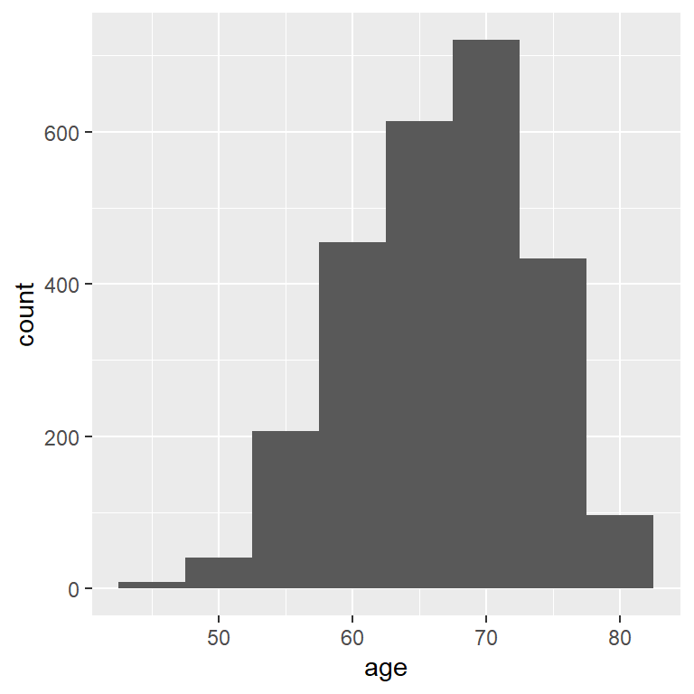

The figure above is a Histogram showing the age distribution.

```r
ggplot(hers_complete_rows) +
  geom_histogram(mapping=aes(age), binwidth = 5)
```

- The histogram above shows that majority of the subjects were older women, proving that the subjects were likely of post-menopausal age.

Age distribution of cohorts:

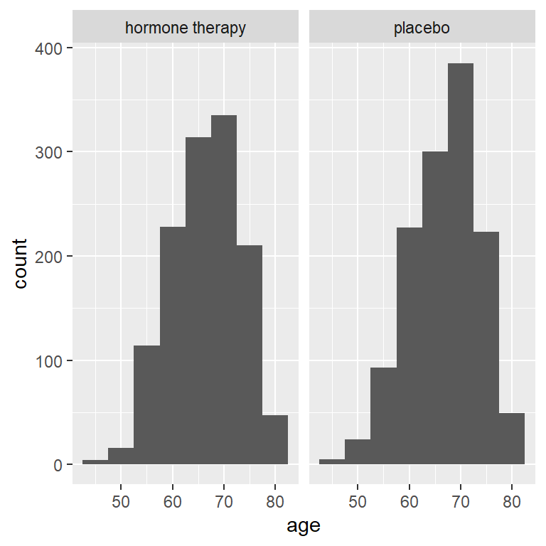

The figure above is a Histogram showing the age distribution bewteen cohorts.

```r
ggplot(hers_complete_rows) +
  geom_histogram(mapping=aes(age), binwidth = 5) +
  facet_wrap(~HT)
```

- The histogram above shows that there was a somewhat similar distribution of the age between both the hormone therapy and placebo cohorts.

Next, we do some bar chats for the Categorical Variables to compare their distribution between both study groups.

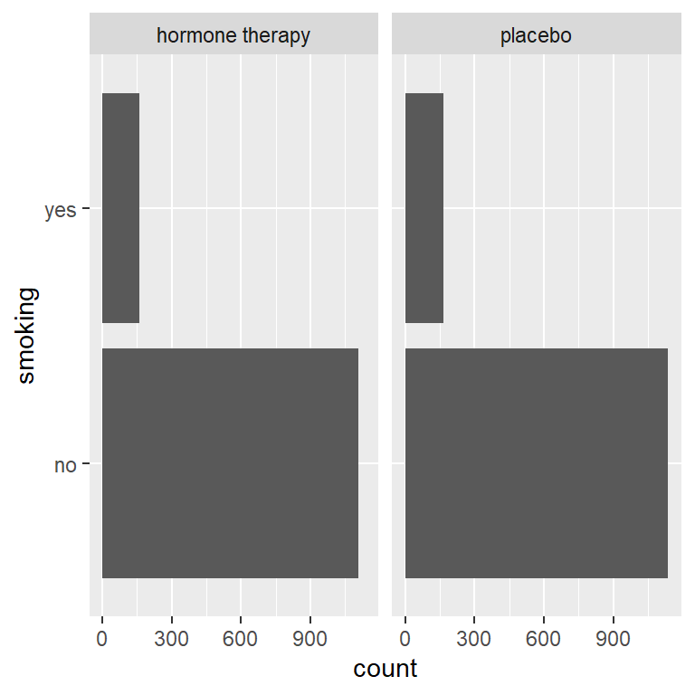

```r
# Barcharts for Categorical variables
# smoking, exercise, drinkany, raceth, medcond, htnmeds, statins, diabetes, dmpills, insulin
ggplot() +
  geom_bar(data = hers_complete_rows, mapping = aes(y=smoking)) + facet_wrap(~ HT)
```

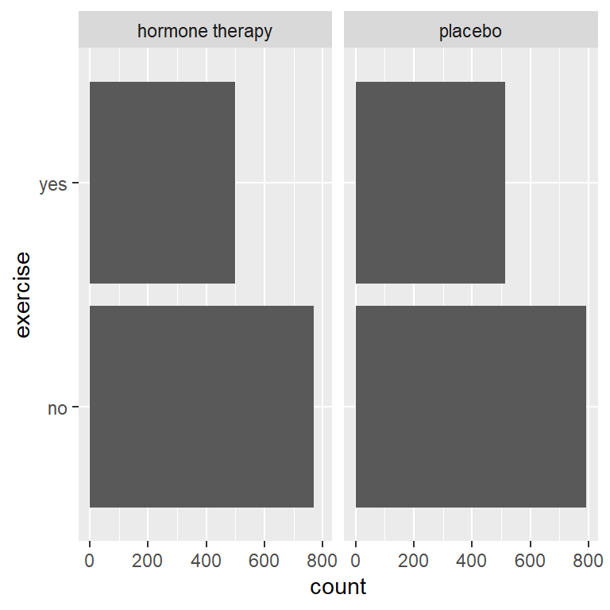

```r
ggplot() +
  geom_bar(data = hers_complete_rows, mapping = aes(y=exercise)) + facet_wrap(~ HT)
```

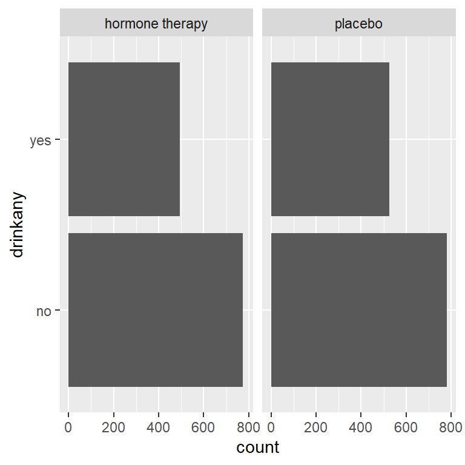

```r
ggplot() +
  geom_bar(data = hers_complete_rows, mapping = aes(y=drinkany)) + facet_wrap(~ HT)
```

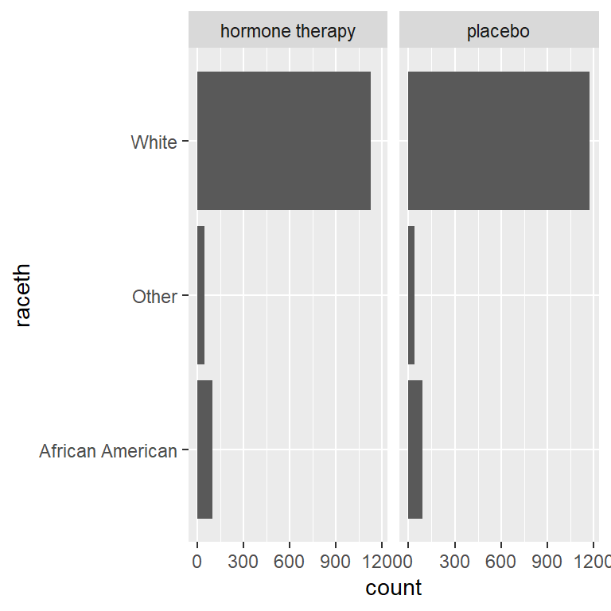

```r
ggplot() +
  geom_bar(data = hers_complete_rows, mapping = aes(y=raceth)) + facet_wrap(~ HT)
```

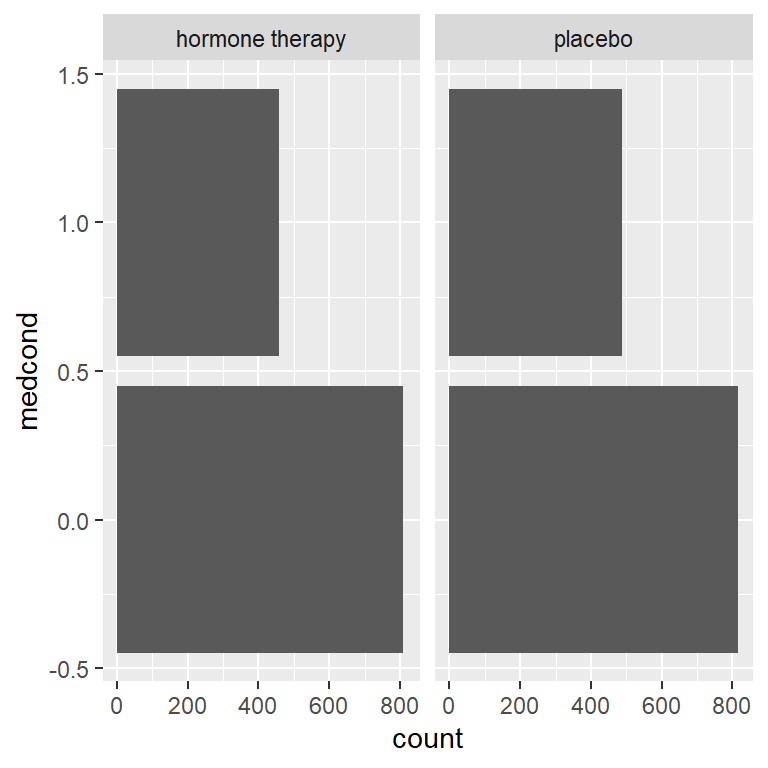

```r
ggplot() +
  geom_bar(data = hers_complete_rows, mapping = aes(y=medcond)) + facet_wrap(~ HT)
```

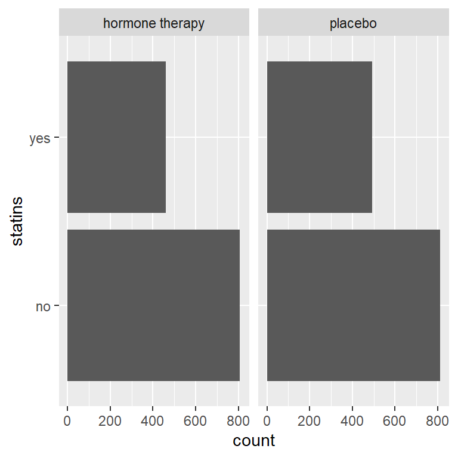

```r
ggplot() +
  geom_bar(data = hers_complete_rows, mapping = aes(y=statins)) + facet_wrap(~ HT)
```

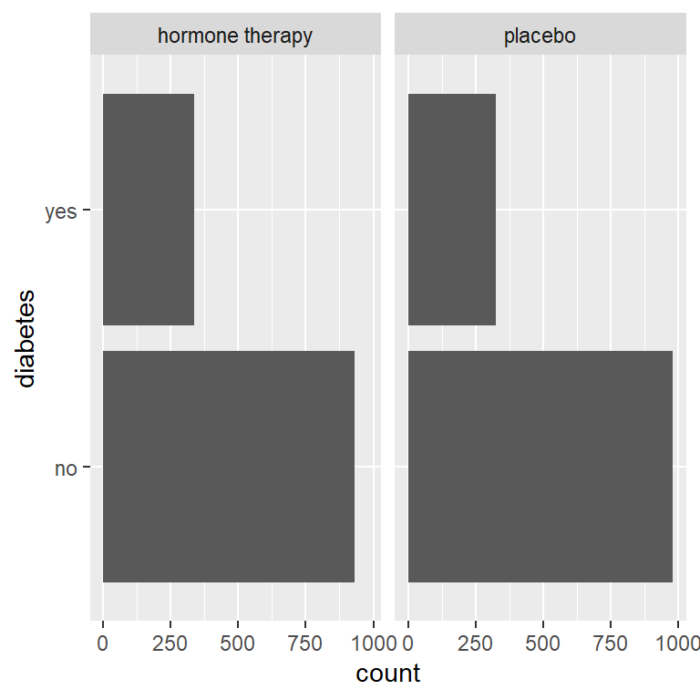

```r
ggplot() +
  geom_bar(data = hers_complete_rows, mapping = aes(y=diabetes)) + facet_wrap(~ HT)
```

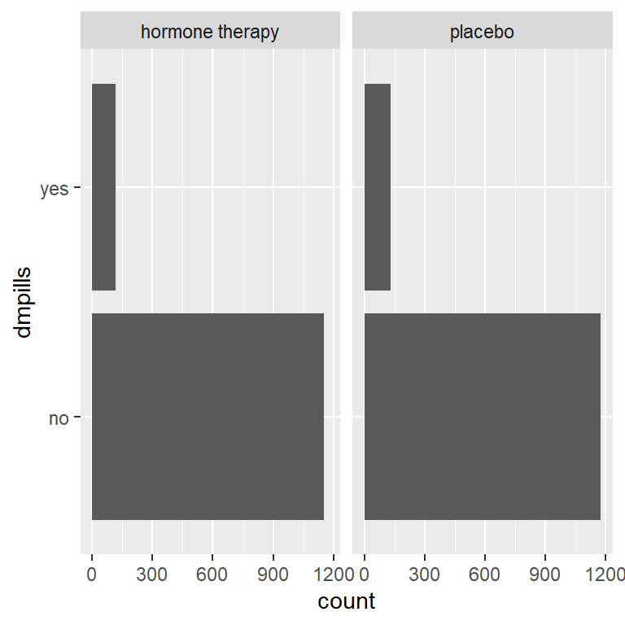

```r
ggplot() +
  geom_bar(data = hers_complete_rows, mapping = aes(y=dmpills)) + facet_wrap(~ HT)
```

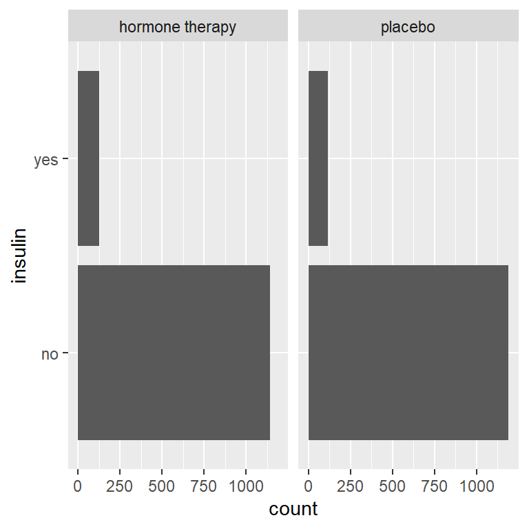

```r
ggplot() +
  geom_bar(data = hers_complete_rows, mapping = aes(y=insulin)) + facet_wrap(~ HT)
```

The bar charts show that there was an even distribution of subjects based on their categorical variables between both groups. As an example, the distribution implies that there was an equal amount of smokers/non-smokers in the Hormone Therapy group and the Placebo Group.

Below is a summary of the average values of all numerical variables.

```r
dtf <- hers_complete_rows %>%
  group_by(HT) %>%
  summarise_if(is.numeric, mean) %>%
  select(-medcond, -age10, -SBP, -DBP)

dtf2 <- hers_complete_rows %>%
  group_by(HT) %>%
  summarise_if(is.numeric, sd) %>%
  select(-medcond, -age10, -SBP, -DBP)

dtf_colnames <- colnames(dtf)[-1]

dtfX <- dtf %>% pivot_longer(dtf_colnames, names_to="Variable", values_to="mean") %>%
  pivot_wider(names_from=HT, values_from=mean)
dtfX2 <- dtf2 %>% pivot_longer(dtf_colnames, names_to="Variable", values_to="mean") %>%
  pivot_wider(names_from=HT, values_from=mean)
colnames(dtfX2) <- c("Variable", "hormone Therapy (sd)", "placebo (sd)")
dtfY <- cbind(dtfX[1], dtfX[2], dtfX2[2], dtfX[3], dtfX2[3])

dtfY %>% mutate(across(2:5,round,3)) %>% kable()
```

| Variable | hormone therapy | hormone Therapy (sd) | placebo | placebo (sd) |
| --- | --- | --- | --- | --- |
| age | 66.443 | 6.645 | 66.811 | 6.653 |
| weight | 72.871 | 14.514 | 72.438 | 14.695 |
| BMI | 28.585 | 5.417 | 28.497 | 5.477 |
| waist | 91.849 | 13.794 | 91.360 | 13.117 |
| WHR | 0.870 | 0.081 | 0.868 | 0.078 |
| glucose | 110.050 | 36.208 | 111.090 | 37.359 |
| weight1 | 71.726 | 14.657 | 72.134 | 15.062 |
| BMI1 | 28.205 | 5.481 | 28.434 | 5.590 |
| waist1 | 90.865 | 13.642 | 91.191 | 13.340 |
| WHR1 | 0.866 | 0.079 | 0.867 | 0.076 |
| glucose1 | 111.785 | 41.184 | 116.636 | 46.237 |
| tchol | 227.700 | 41.438 | 228.537 | 40.363 |
| LDL | 144.947 | 38.311 | 144.573 | 37.330 |
| HDL | 49.972 | 13.089 | 50.635 | 13.171 |
| TG | 163.905 | 62.676 | 166.645 | 63.548 |
| tchol1 | 214.818 | 39.352 | 223.479 | 42.366 |
| LDL1 | 124.690 | 36.670 | 139.917 | 39.676 |
| HDL1 | 54.218 | 14.255 | 49.498 | 13.129 |
| TG1 | 179.547 | 81.857 | 170.320 | 79.489 |

The table above shows that (on the average) the women had a BMI of 28. This implies that they were mostly overweight and because overweight persons are prone to CHD, it is clear that the subjects comply with the ideal subject criteria.

We move on to Box plots for the Numerical Variables.

```r
#FUNCTION FOR BOXPLOT OF BOTH COHORTS
#TO COMPARE THE OUTCOME OF A VARIABLE BEFORE AND AFTER 1 YEAR OF THERAPY
compare_boxplots <- function(vars) {
  hers_complete_rows %>%
    pivot_longer(cols=starts_with(vars) ) %>%
    ggplot() +
    geom_boxplot(mapping = aes(x=name,y=value)) +
    facet_wrap(~HT)
}
```

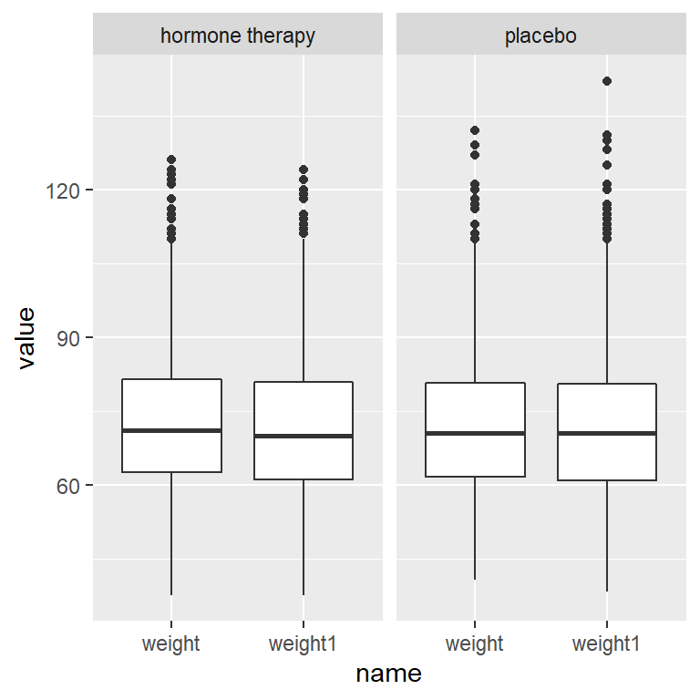

The figure above is a Boxplot showing the weight distribution bewteen cohorts.

```r
compare_boxplots("weight")
```

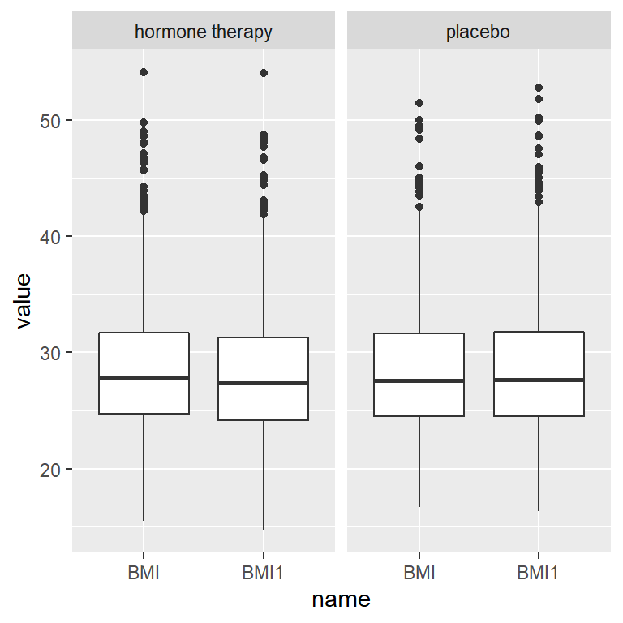

The figure above is a Boxplot showing the BMI distribution bewteen cohorts.

```r
compare_boxplots("BMI")
```

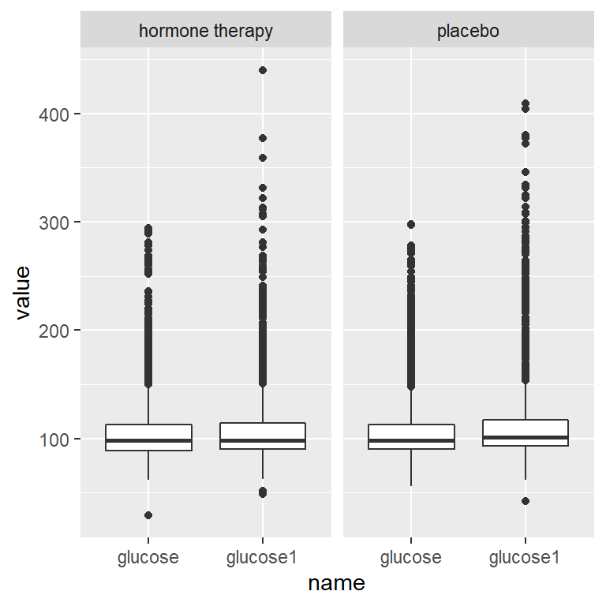

The figure above is a Boxplot showing the glucose distribution bewteen cohorts.

```r
compare_boxplots("glucose")
```

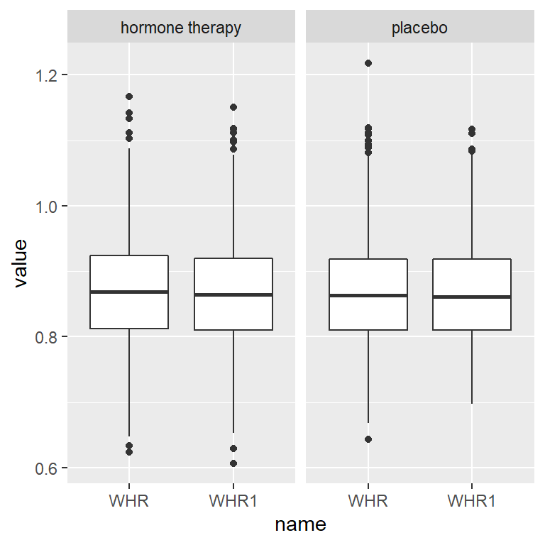

The figure above is a Boxplot showing the Waist to Hip Ratio distribution bewteen cohorts.

```r
compare_boxplots("WHR")
```

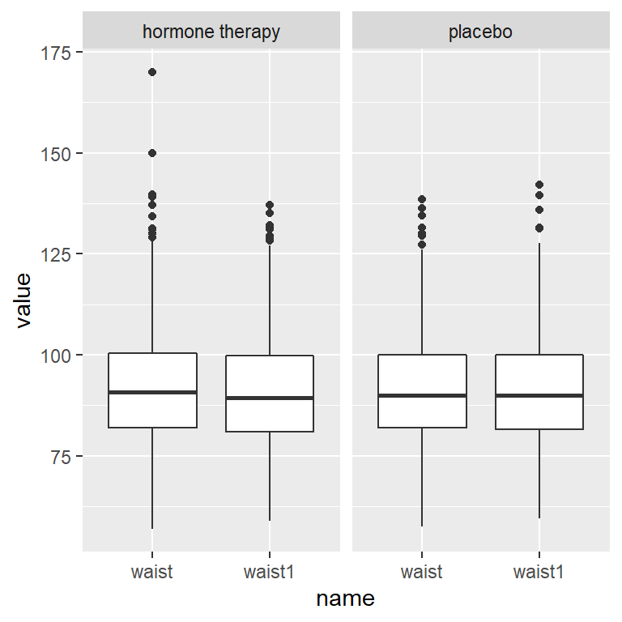

The figure above is a Boxplot showing the waist distribution bewteen cohorts.

```r
compare_boxplots("waist")
```

> NOTE:

> The boxplots for anthropometric measurements- Weight, Body Mass Index (BMI), Fasting glucose (glucose), Waist to Hip ratio (WHR), and Waist circumference (waist) of the test and placebo subjects are similar at baseline and one year into treatment.

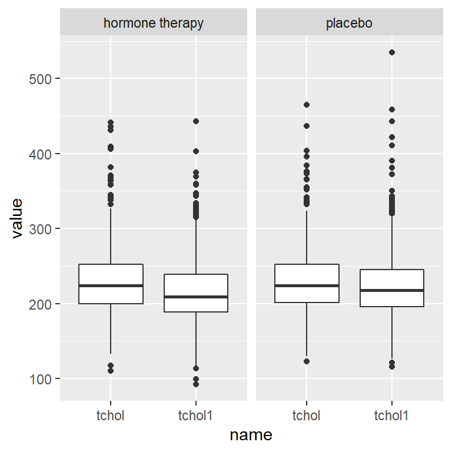

The figure above is a Boxplot showing the tchol distribution bewteen cohorts.

```r
compare_boxplots("tchol")
```

- At baseline, the Total Cholesterol (TCHOL) of the test subjects and those on placebo look similar.
- One year into treatment, the Total Cholesterol (TCHOL1) of the test subjects have a lower MEDIAN than the placebo subjects.
- For the test subjects, the MEDIAN value of the Total Cholesterol by one year into treatment (TCHOL1) is lower than it was at the baseline (TCHOL).

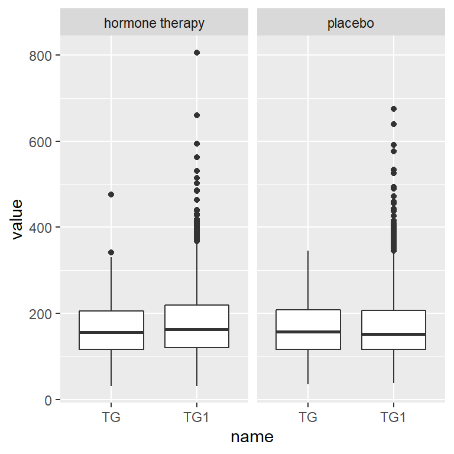

The figure above is a Boxplot showing the Triglyceride (TG) distribution bewteen cohorts.

```r
compare_boxplots("TG")
```

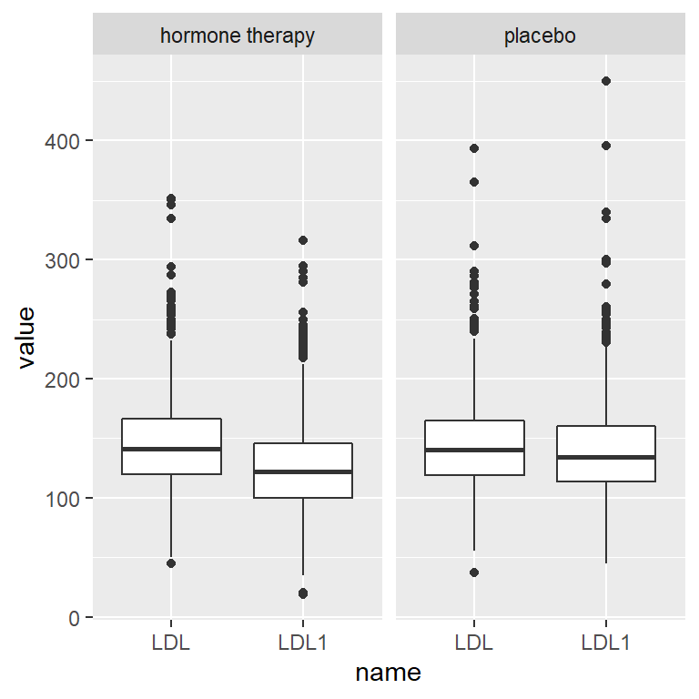

The figure above is a Boxplot showing the Low Density Lipoporotein (LDL) distribution bewteen cohorts.

```r
compare_boxplots("LDL")
```

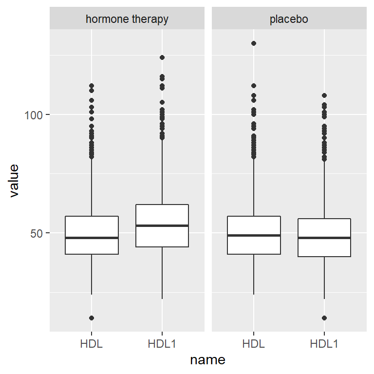

The figure above is a Boxplot showing the High Density Lipoporotein (HDL) distribution between cohorts.

```r
compare_boxplots("HDL")
```

- At baseline, the High Density Lipoporotein (HDL) of the test subjects and those on placebo look similar.
- One year into treatment, the High Density Lipoporotein (HDL1) of the test subjects have a higher MEDIAN than the placebo subjects.
- For the test subjects, the MEDIAN value of the High Density Lipoporotein by one year into treatment (HDL1) is higher than it was at the baseline (HDL).

```r
# stats test t-test
vars <- c("weight", "BMI", "WHR", "glucose", "tchol", "HDL", "LDL", "TG")
```

# Statistical Analyses

For the purposes of this analysis, we choose to focus on the following variables, comparing them at the baseline and on one year of follow-up.

**Blood parameters**:

These are the varaibles that best represents the “coronary heart disease” outcome within the provided dataset:

1. TCHOL = Total cholesterol ($mg/dL$)
2. HDL = High Density Lipoprotein cholesterol ($mg/dL$)
3. LDL = Low Density Lipoprotein cholesterol ($mg/dL$)
4. TG = Triglycerides ($mg/dL$)
5. Glucose = Fasting glucose ($mg/dL$)

## Independent T-tests between Hormone Therapy and Control Group.

Our approach was to examine the significant differences found on the blood test parameters at baseline and one year into therapy across the two groups. This means that we tested to see if there was any difference between the baseline values of the hormone therapy and the placebo therapy group, then between the values derived after one year into therapy.

```r
#FUNCTION FOR INDEPENDENT T-TEST BETWEEN HORMONE THERPAY AND PLACEBO GROUPS.
t.test.b <- function(var, var1) {
  baseline <- rlang::call2(
    expr(statsr::inference),
    enexpr(var),
    x = expr(HT),
    data = expr(hers_complete_rows),
    type = "ht",
    statistic = "mean",
    method = "theoretical",
    alternative = "twosided"
  )

  oneyear <- rlang::call2(
    expr(statsr::inference),
    enexpr(var1),
    x = expr(HT),
    data = expr(hers_complete_rows),   #USING ONLY DATA FROM THE COMPLETE ROWS
    type = "ht",
    statistic = "mean",
    method = "theoretical",
    alternative = "twosided"
  )

  print(eval(baseline))
  print(eval(oneyear))
}
```

### Blood Parameters

**Total Cholesterol (tchol, tchol1)**

```r
t.test.b(tchol, tchol1)
```

```
Response variable: numerical
Explanatory variable: categorical (2 levels)
n_hormone therapy = 1268, y_bar_hormone therapy = 227.6995, s_hormone therapy = 41.4384
n_placebo = 1306, y_bar_placebo = 228.5368, s_placebo = 40.3631
H0: mu_hormone therapy =  mu_placebo
HA: mu_hormone therapy != mu_placebo
t = -0.5191, df = 1267
p_value = 0.6038
```

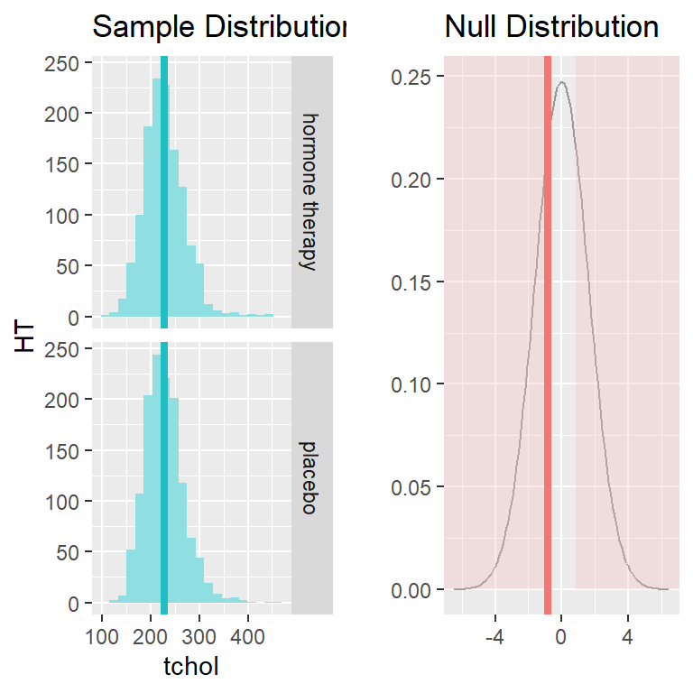

```
$SE
[1] 1.61297

$df
[1] 1267

$t
[1] -0.5190589

$p_value
[1] 0.6038103

Response variable: numerical
Explanatory variable: categorical (2 levels)
n_hormone therapy = 1268, y_bar_hormone therapy = 214.8178, s_hormone therapy = 39.3521
n_placebo = 1306, y_bar_placebo = 223.4793, s_placebo = 42.366
H0: mu_hormone therapy =  mu_placebo
HA: mu_hormone therapy != mu_placebo
t = -5.3762, df = 1267
p_value = < 0.0001
```

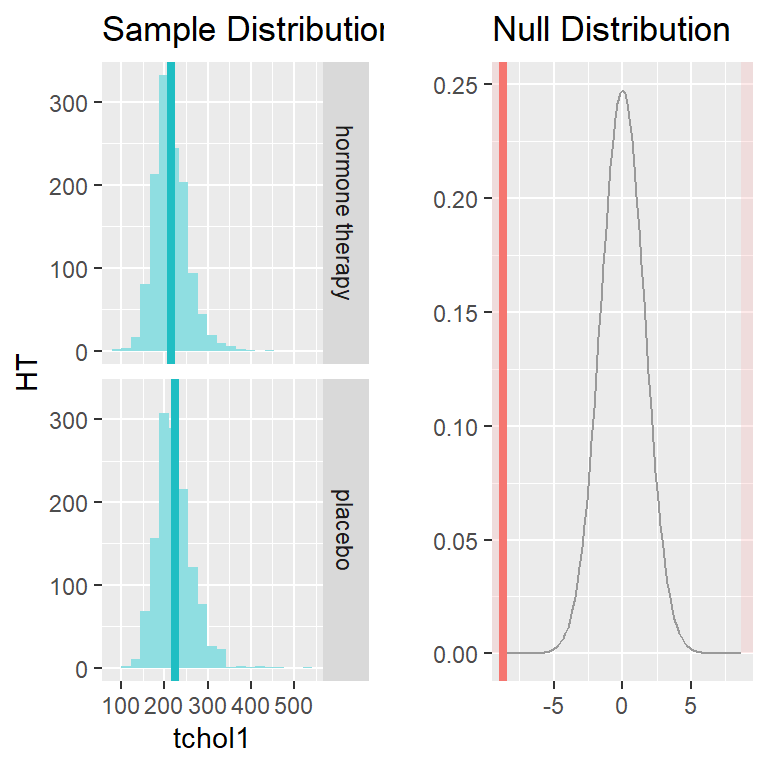

```
$SE
[1] 1.611092

$df
[1] 1267

$t
[1] -5.37617

$p_value
[1] 9.050198e-08
```

**Triglycerides (TG, TG1)**

```r
t.test.b(TG, TG1)
```

```
Response variable: numerical
Explanatory variable: categorical (2 levels)
n_hormone therapy = 1268, y_bar_hormone therapy = 163.9046, s_hormone therapy = 62.676
n_placebo = 1306, y_bar_placebo = 166.6447, s_placebo = 63.5478
H0: mu_hormone therapy =  mu_placebo
HA: mu_hormone therapy != mu_placebo
t = -1.1013, df = 1267
p_value = 0.271
```

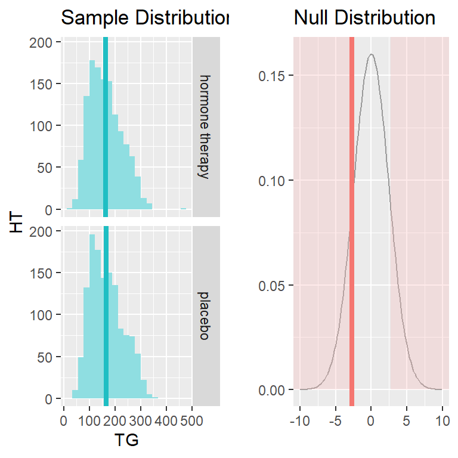

```
$SE
[1] 2.488

$df
[1] 1267

$t
[1] -1.101344

$p_value
[1] 0.2709563

Response variable: numerical
Explanatory variable: categorical (2 levels)
n_hormone therapy = 1268, y_bar_hormone therapy = 179.5465, s_hormone therapy = 81.8575
n_placebo = 1306, y_bar_placebo = 170.3201, s_placebo = 79.4888
H0: mu_hormone therapy =  mu_placebo
HA: mu_hormone therapy != mu_placebo
t = 2.9, df = 1267
p_value = 0.0038
```

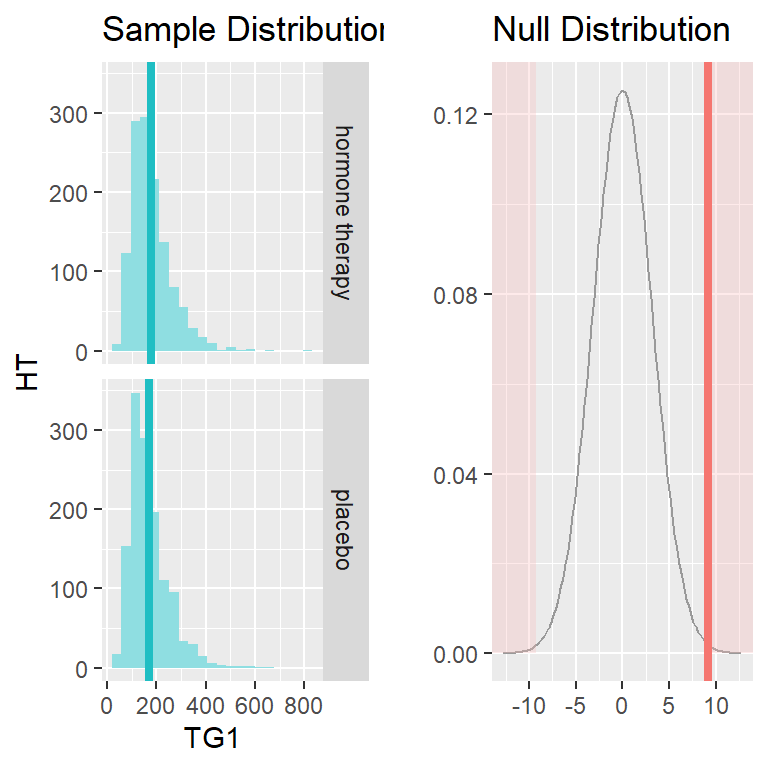

```
$SE
[1] 3.18158

$df
[1] 1267

$t
[1] 2.899965

$p_value
[1] 0.003796435
```

**High Density Lipoprotein (HDL)**

```r
t.test.b(HDL, HDL1)
```

```
Response variable: numerical
Explanatory variable: categorical (2 levels)
n_hormone therapy = 1268, y_bar_hormone therapy = 49.9716, s_hormone therapy = 13.0895
n_placebo = 1306, y_bar_placebo = 50.6348, s_placebo = 13.171
H0: mu_hormone therapy =  mu_placebo
HA: mu_hormone therapy != mu_placebo
t = -1.2811, df = 1267
p_value = 0.2004
```

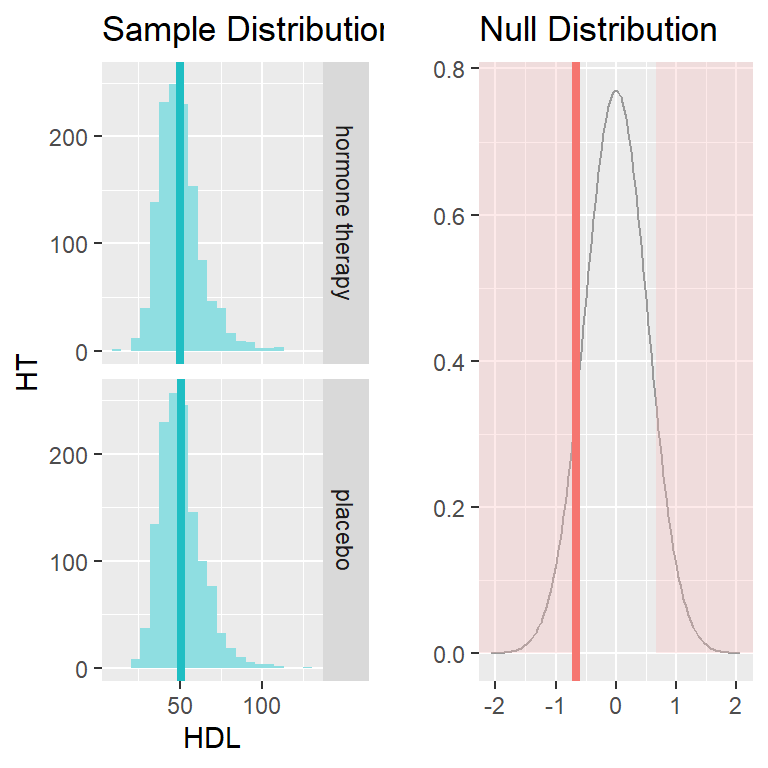

```
$SE
[1] 0.51764

$df
[1] 1267

$t
[1] -1.28111

$p_value
[1] 0.2003894

Response variable: numerical
Explanatory variable: categorical (2 levels)
n_hormone therapy = 1268, y_bar_hormone therapy = 54.2185, s_hormone therapy = 14.2551
n_placebo = 1306, y_bar_placebo = 49.4985, s_placebo = 13.1289
H0: mu_hormone therapy =  mu_placebo
HA: mu_hormone therapy != mu_placebo
t = 8.7311, df = 1267
p_value = < 0.0001
```

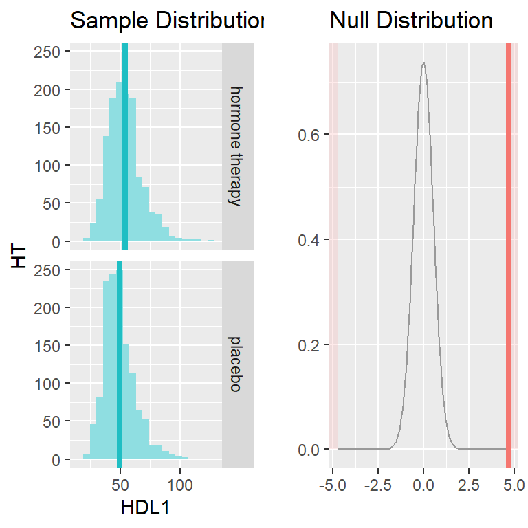

```
$SE
[1] 0.5405927

$df
[1] 1267

$t
[1] 8.731132

$p_value
[1] 7.81864e-18
```

**Low Density Lipoprotein (LDL)**

```r
t.test.b(LDL, LDL1)
```

```
Response variable: numerical
Explanatory variable: categorical (2 levels)
n_hormone therapy = 1268, y_bar_hormone therapy = 144.947, s_hormone therapy = 38.3108
n_placebo = 1306, y_bar_placebo = 144.573, s_placebo = 37.3297
H0: mu_hormone therapy =  mu_placebo
HA: mu_hormone therapy != mu_placebo
t = 0.2507, df = 1267
p_value = 0.8021
```

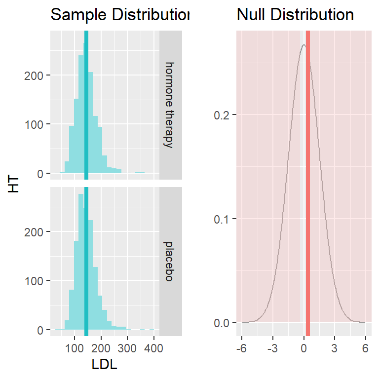

```
$SE
[1] 1.49148

$df
[1] 1267

$t
[1] 0.2507279

$p_value
[1] 0.8020651

Response variable: numerical
Explanatory variable: categorical (2 levels)
n_hormone therapy = 1268, y_bar_hormone therapy = 124.6901, s_hormone therapy = 36.67
n_placebo = 1306, y_bar_placebo = 139.9168, s_placebo = 39.6763
H0: mu_hormone therapy =  mu_placebo
HA: mu_hormone therapy != mu_placebo
t = -10.1156, df = 1267
p_value = < 0.0001
```

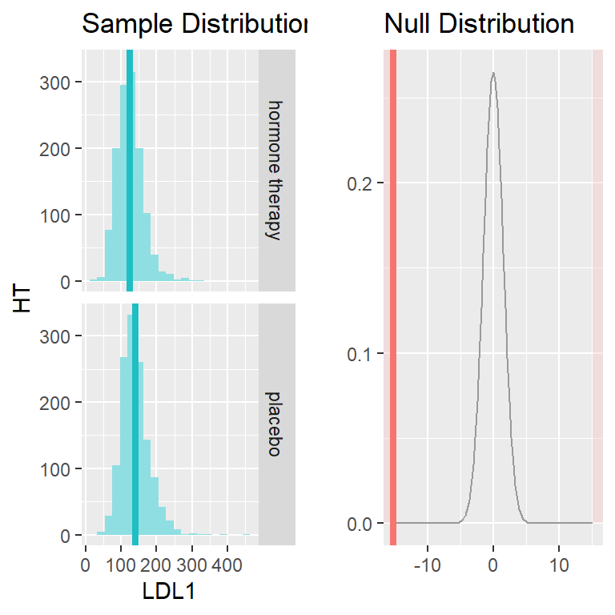

```
$SE
[1] 1.505274

$df
[1] 1267

$t
[1] -10.11562

$p_value
[1] 3.479483e-23
```

**Glucose**

```r
t.test.b(glucose, glucose1)
```

```
Response variable: numerical
Explanatory variable: categorical (2 levels)
n_hormone therapy = 1268, y_bar_hormone therapy = 110.0497, s_hormone therapy = 36.2079
n_placebo = 1306, y_bar_placebo = 111.0896, s_placebo = 37.3595
H0: mu_hormone therapy =  mu_placebo
HA: mu_hormone therapy != mu_placebo
t = -0.7172, df = 1267
p_value = 0.4734
```

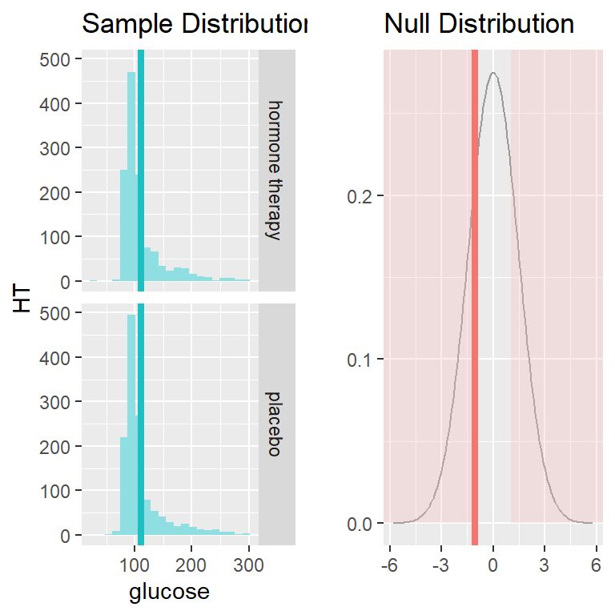

```
$SE
[1] 1.450044

$df
[1] 1267

$t
[1] -0.7171523

$p_value
[1] 0.4734123

Response variable: numerical
Explanatory variable: categorical (2 levels)
n_hormone therapy = 1268, y_bar_hormone therapy = 111.7855, s_hormone therapy = 41.1844
n_placebo = 1306, y_bar_placebo = 116.6363, s_placebo = 46.237
H0: mu_hormone therapy =  mu_placebo
HA: mu_hormone therapy != mu_placebo
t = -2.8125, df = 1267
p_value = 0.005
```

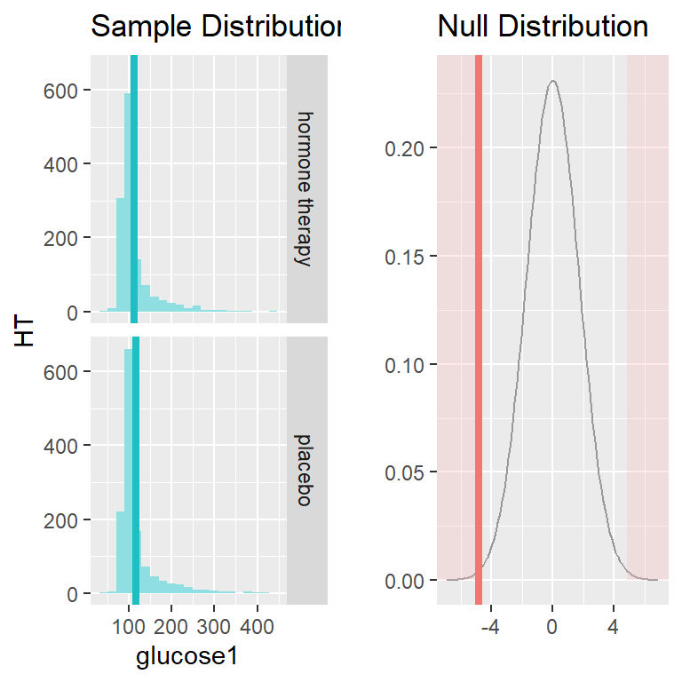

```
$SE
[1] 1.724706

$df
[1] 1267

$t
[1] -2.81254

$p_value
[1] 0.004991051
```

**RESULTS**

Based on the t-test, total cholesterol, triglycerides, HDL, LDL, and fasting glucose levels are not significantly different between treatment and control group at baseline, but there is a significant and statistically proven difference by one year of follow-up.